# Data Exploration : PISA 2012 Test

#### *by Mehdi Iddar*

Data visualization is an important skill that is used in many parts of the data analysis process. Exploratory data visualization generally occurs during and after the data wrangling process, and is the main method to understand the patterns and relationships present in the data.

Explanatory data visualization techniques are used after generating findings, and are used to help communicate the results to others.

- Part I: Introduction
- Part II: Dataset wrangling
- Part III : Exploratory data analysis
  - 1. Univariate exploration and analysis
  - 2. Bivariate exploration and analysis
  - 3. Multivariate exploration and analysis

## Part I: Introduction

The Program for International Student Assessment (PISA) is a system of international assessments that allows countries to compare outcomes of learning as students near the end of compulsory schooling. PISA core assessments measure the performance of 15-year-old students in mathematics, science, and reading literacy every 3 years. Coordinated by the Organization for Economic Cooperation and Development (OECD), PISA was first implemented in 2000 in 32 countries. It has since grown to 65 education systems in 2012.

PISA is a survey of students' skills and knowledge as they approach the end of compulsory education. It is not a conventional school test. Rather than examining how well students have learned the school curriculum, it looks at how well prepared they are for life beyond school.

## Part II: Dataset wrangling

```python
import zipfile
import pandas as pd
import numpy as np
import matplotlib.pyplot as plt
import seaborn as sns
%matplotlib inline
sns.set()
```

```python
# use extractall to extract the zipped file
"""with zipfile.ZipFile("pisa2012.csv.zip", 'r') as zip_ref:
    zip_ref.extractall("targetdir")"""
```

```
'with zipfile.ZipFile("pisa2012.csv.zip", \'r\') as zip_ref:\n    zip_ref.extractall("targetdir")'
```

```python
# read the unzipped file as .csv
pisa = pd.read_csv("C:\\Users\\iddar\\Desktop\\Communicate Data Findings\\targetdir\\pisa2012.csv", encoding = "ISO-8859-1")
```

```python
pisa.head(2)
```

|  | Unnamed: 0 | CNT | SUBNATIO | STRATUM | OECD | NC | SCHOOLID | STIDSTD | ST01Q01 | ST02Q01 | ST03Q01 | ST03Q02 | ST04Q01 | ST05Q01 | ST06Q01 | ST07Q01 | ST07Q02 | ST07Q03 | ST08Q01 | ST09Q01 | ST115Q01 | ST11Q01 | ST11Q02 | ST11Q03 | ST11Q04 | ST11Q05 | ST11Q06 | ST13Q01 | ST14Q01 | … |
| --- | --- | --- | --- | --- | --- | --- | --- | --- | --- | --- | --- | --- | --- | --- | --- | --- | --- | --- | --- | --- | --- | --- | --- | --- | --- | --- | --- | --- | --- | --- |
| 0 | 1 | Albania | 80000 | ALB0006 | Non-OECD | Albania | 1 | 1 | 10 | 1.0 | 2 | 1996 | Female | No | 6.0 | No, never | No, never | No, never | None | None | 1.0 | Yes | Yes | Yes | Yes | NaN | NaN | <ISCED level 3A> | No | … |
| 1 | 2 | Albania | 80000 | ALB0006 | Non-OECD | Albania | 1 | 2 | 10 | 1.0 | 2 | 1996 | Female | Yes, for more than one year | 7.0 | No, never | No, never | No, never | One or two times | None | 1.0 | Yes | Yes | NaN | Yes | NaN | NaN | <ISCED level 3A> | Yes | … |

```python
# data frame shape
print (pisa.shape)
```

```
(485490, 636)
```

The dataset provided has 636 variables (columns) and 485490 observations (rows).  
We are interested in exploring the formatting of all columns (variables), hence we will display all of them

```python
pd.set_option('display.max_rows', 636)
pd.set_option('display.max_columns', 636)
pisa.head(2)
```

|  | Unnamed: 0 | CNT | SUBNATIO | STRATUM | OECD | NC | SCHOOLID | STIDSTD | ST01Q01 | ST02Q01 | ST03Q01 | ST03Q02 | ST04Q01 | ST05Q01 | ST06Q01 | ST07Q01 | ST07Q02 | ST07Q03 | ST08Q01 | ST09Q01 | ST115Q01 | ST11Q01 | ST11Q02 | ST11Q03 | ST11Q04 | ST11Q05 | ST11Q06 | ST13Q01 | ST14Q01 | … |
| --- | --- | --- | --- | --- | --- | --- | --- | --- | --- | --- | --- | --- | --- | --- | --- | --- | --- | --- | --- | --- | --- | --- | --- | --- | --- | --- | --- | --- | --- | --- |
| 0 | 1 | Albania | 80000 | ALB0006 | Non-OECD | Albania | 1 | 1 | 10 | 1.0 | 2 | 1996 | Female | No | 6.0 | No, never | No, never | No, never | None | None | 1.0 | Yes | Yes | Yes | Yes | NaN | NaN | <ISCED level 3A> | No | … |
| 1 | 2 | Albania | 80000 | ALB0006 | Non-OECD | Albania | 1 | 2 | 10 | 1.0 | 2 | 1996 | Female | Yes, for more than one year | 7.0 | No, never | No, never | No, never | One or two times | None | 1.0 | Yes | Yes | NaN | Yes | NaN | NaN | <ISCED level 3A> | Yes | … |

Throughout the following exploration, I will trry to find answers to these questions :

- What is the proportion of male and female students within the dataset ?
- Are there differences in achievement based on gender ?
- Are there differences in achievement based on student attitudes?
- What are countries with top math, science, reading scores ?

After checking the dictionnary of PISA to know the meaning of each variable, my analysis will be focused on the following columns :

**STIDSTD**: "Student ID"  
**CNT** : "Country code 3-character"  
**ST04Q01** : "Gender"  
**ST06Q01** : "Age"  
**ST81Q01**: "Disciplinary Climate - Students Don’t Listen"  
**ST81Q02**: "Disciplinary Climate - Noise and Disorder"  
**ST81Q03**: "Disciplinary Climate - Teacher Has to Wait Until its Quiet"  
**ST81Q04**: "Disciplinary Climate - Students Don’t Work Well"  
**ST81Q05**: "Disciplinary Climate - Students Start Working Late"  
**PV1MATH**: "Plausible value 1 in mathematics"  
**PV2MATH**: "Plausible value 2 in mathematics"  
**PV3MATH**: "Plausible value 3 in mathematics"  
**PV4MATH**: "Plausible value 4 in mathematics"  
**PV5MATH**: "Plausible value 5 in mathematics"  
**PV1READ**: "Plausible value 1 in reading"  
**PV2READ**: "Plausible value 2 in reading"  
**PV3READ**: "Plausible value 3 in reading"  
**PV4READ**: "Plausible value 4 in reading"  
**PV5READ**: "Plausible value 5 in reading"  
**PV1SCIE**: "Plausible value 1 in science"  
**PV2SCIE**: "Plausible value 2 in science"  
**PV3SCIE**: "Plausible value 3 in science"  
**PV4SCIE**: "Plausible value 4 in science"  
**PV5SCIE**: "Plausible value 5 in science"

```python
# Subset dataset
df = pisa[['STIDSTD','CNT' , 'ST06Q01', 'ST04Q01','ST81Q01','ST81Q02','ST81Q03', 'ST81Q04', 'ST81Q05',
           'PV1MATH', 'PV2MATH', 'PV3MATH', 'PV4MATH', 'PV5MATH', 'PV1READ', 'PV2READ',
           'PV3READ','PV4READ', 'PV5READ', 'PV1SCIE', 'PV2SCIE', 'PV3SCIE', 'PV4SCIE', 'PV5SCIE']]
```

```python
df.sample(2)
```

|  | STIDSTD | CNT | ST06Q01 | ST04Q01 | ST81Q01 | ST81Q02 | ST81Q03 | ST81Q04 | ST81Q05 | PV1MATH | PV2MATH | PV3MATH | PV4MATH | PV5MATH | PV1READ | PV2READ | PV3READ | PV4READ | PV5READ | PV1SCIE | PV2SCIE | PV3SCIE | PV4SCIE | PV5SCIE |
| --- | --- | --- | --- | --- | --- | --- | --- | --- | --- | --- | --- | --- | --- | --- | --- | --- | --- | --- | --- | --- | --- | --- | --- | --- |
| 251134 | 10545 | Italy | 6.0 | Female | Some Lessons | Most Lessons | Every Lesson | Every Lesson | Every Lesson | 490.8942 | 460.5157 | 462.0735 | 462.8525 | 437.1475 | 555.3856 | 506.1384 | 489.4578 | 497.4009 | 465.6285 | 516.1693 | 487.2622 | 474.2074 | 463.0175 | 450.8952 |
| 352817 | 3309 | Montenegro | 7.0 | Female | NaN | NaN | NaN | NaN | NaN | 374.0536 | 398.9796 | 402.0953 | 398.2007 | 368.6010 | 399.7008 | 435.4448 | 453.7139 | 417.9699 | 415.5870 | 342.7266 | 353.9164 | 361.3764 | 387.4860 | 331.5367 |

Let's save the new dataset to a .csv file.

```python
df.to_csv('pisa_analysis.csv', index=False)
```

```python
df = pd.read_csv('pisa_analysis.csv')
```

Rename columns and aplly lowercase to all columns name

```python
df.rename({ 'STIDSTD' : "Student ID", 'CNT' : "country" , 'ST04Q01' : "gender", 'ST06Q01':"Age",
             'ST81Q01': "students don’t listen",
             'ST81Q02': "noise and disorder", 'ST81Q03': "teacher has to wait until its quiet",
             'ST81Q04': "students don’t work well", 'ST81Q05': "students start working late"}, axis = 'columns', inplace = True)
```

```python
# lowercase all columns name
df.columns = [x.lower() for x in df.columns]
```

In order to be able to answer questions about the disciplinary climate and how its affect achievements, I need apply some tidyness transformations to restructure the disciplinary climate columns.

For this I used the 'melt' function

```python
# id_vars : Here we have set the variables (columns) that we want to leave unaffected
# I used numpy's 'setdiff1d' to substract the unaffected list.
all_columns = df.columns.tolist()
disciplinary_columns = ['students don’t listen' , 'noise and disorder' , 'teacher has to wait until its quiet',
                       'students don’t work well', 'students start working late']
unaffected_discipline = np.setdiff1d(all_columns,disciplinary_columns)
unaffected_discipline = unaffected_discipline.tolist()
# Variables not included in this list will become rows in a new column (which has the name given by “var_name”)
# The values belonging to the original rows/columns are found in a new column with a name given by “value_name”
df = pd.melt(df, id_vars = unaffected_discipline,var_name='discipline', value_name='discipline level')
```

```python
df.sample()
```

|  | age | country | gender | pv1math | pv1read | pv1scie | pv2math | pv2read | pv2scie | pv3math | pv3read | pv3scie | pv4math | pv4read | pv4scie | pv5math | pv5read | pv5scie | student id | discipline | discipline level |
| --- | --- | --- | --- | --- | --- | --- | --- | --- | --- | --- | --- | --- | --- | --- | --- | --- | --- | --- | --- | --- | --- |
| 667376 | 6.0 | Finland | Male | 428.5792 | 435.4379 | 519.1533 | 427.0213 | 481.1488 | 488.3812 | 405.99 | 419.399 | 477.1913 | 389.6323 | 380.1037 | 404.4573 | 416.1162 | 395.3407 | 383.0101 | 6212 | noise and disorder | NaN |

I nedd to add three new columns which calculate the average of plausible scores determines the PISA score of a student in a particular subject

```python
df['math score'] = (df['pv1math'] + df['pv2math'] + df['pv3math'] + df['pv4math'] + df['pv5math']) / 5
df['reading score'] = (df['pv1read'] + df['pv2read'] + df['pv3read'] + df['pv4read'] + df['pv5read']) / 5
df['science score'] = (df['pv1scie'] + df['pv2scie'] + df['pv3scie'] + df['pv4scie'] + df['pv5scie']) / 5
```

```python
# Drop any further-unnecessary columns
df.drop(columns = ['pv1math', 'pv2math', 'pv3math', 'pv4math', 'pv5math', 'pv1read', 'pv2read', 'pv3read', 'pv4read',
                   'pv5read','pv1scie', 'pv2scie', 'pv3scie', 'pv4scie', 'pv5scie'], inplace = True)
```

```python
df.columns
```

```
Index(['age', 'country', 'gender', 'student id', 'discipline',
       'discipline level', 'math score', 'reading score', 'science score'],
      dtype='object')
```

```python
# Set order of columns
df = df[['student id', 'country', 'gender','age', 'discipline', 'discipline level',
         'math score', 'reading score','science score']]
```

```python
df.sample(2)
```

|  | student id | country | gender | age | discipline | discipline level | math score | reading score | science score |
| --- | --- | --- | --- | --- | --- | --- | --- | --- | --- |
| 760087 | 2935 | Jordan | Male | 6.0 | noise and disorder | NaN | 274.58326 | 279.13882 | 307.01230 |
| 1544137 | 13198 | Canada | Male | 5.0 | students don’t work well | Never or Hardly Ever | 541.21356 | 513.54736 | 537.61656 |

```python
df.info()
```

```
<class 'pandas.core.frame.DataFrame'>
RangeIndex: 2427450 entries, 0 to 2427449
Data columns (total 9 columns):
student id          int64
country             object
gender              object
age                 float64
discipline          object
discipline level    object
math score          float64
reading score       float64
science score       float64
dtypes: float64(4), int64(1), object(4)
memory usage: 166.7+ MB
```

```python
# change gender datatype to categoy
df.gender = df.gender.astype('category')
```

```python
df.to_csv('pisa_clean.csv', index=False)
```

```python
df = pd.read_csv('pisa_clean.csv')
```

## Part III : Exploratory data analysis

### 1. Univariate exploration and analysis

*In this section, we will investigate the distributions of individual variables.*

First, let's explore the distribution of math, reading and science scores using histograms

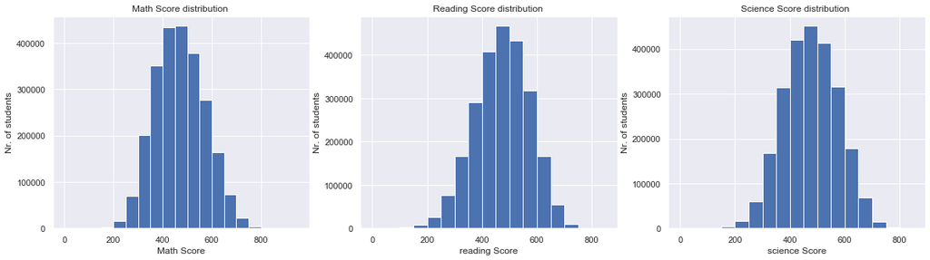

```python
plt.figure(figsize = [20, 5])

plt.subplot(1, 3, 1)
bins_math = np.arange(0,df['math score'].max()+50, 50)
plt.hist(data = df , x = 'math score', bins = bins_math)
plt.xlabel('Math Score');
plt.ylabel('Nr. of students')
plt.title("Math Score distribution ");

plt.subplot(1, 3, 2)
bins_reading = np.arange(0,df['reading score'].max()+50, 50)
plt.hist(data = df , x = 'reading score', bins = bins_reading)
plt.xlabel('reading Score');
plt.ylabel('Nr. of students')
plt.title("Reading Score distribution ");

plt.subplot(1, 3, 3)
science_reading = np.arange(0,df['science score'].max()+50, 50)
plt.hist(data = df , x = 'science score', bins = bins_reading)
plt.xlabel('science Score')
plt.ylabel('Nr. of students')
plt.title("Science Score distribution ");
```

The previous histogram shows that Math scores, reading scores and reading scores are normally distributed. Is there any correlation between math and science scores ? I will try to answer this question in the bivariate exploration part.

What is the proportion of male and female students within the dataset ? Let's explore the proportion of male and female students using pie chart.

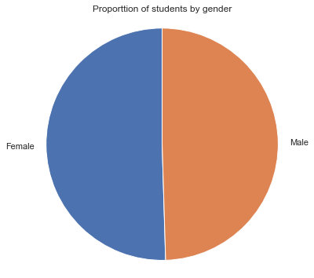

```python
gender_df = df['gender'].value_counts()
plt.figure(figsize = [8, 6])
plt.pie(gender_df, labels=gender_df.index, startangle=90)
plt.axis('square')
plt.title('Proporttion of students by gender');
```

The pie chart show the gender is almost evenly split. However, are there differences in achievement based on gender ? In the next part I will use bivariate exploration to anwser this question.

### 2. Bivariate exploration and analysis

*In this section, we will investigate the relationships between pairs of relevant variables in our data.*

```python
df.head()
```

|  | student id | country | gender | age | discipline | discipline level | math score | reading score | science score |
| --- | --- | --- | --- | --- | --- | --- | --- | --- | --- |
| 0 | 1 | Albania | Female | 6.0 | students don’t listen | Never or Hardly Ever | 366.18634 | 261.01424 | 371.91348 |
| 1 | 2 | Albania | Female | 7.0 | students don’t listen | NaN | 470.56396 | 384.68832 | 478.12382 |
| 2 | 3 | Albania | Female | 6.0 | students don’t listen | NaN | 505.53824 | 405.18154 | 486.60946 |
| 3 | 4 | Albania | Female | 6.0 | students don’t listen | Never or Hardly Ever | 449.45476 | 477.46376 | 453.97240 |
| 4 | 5 | Albania | Female | 6.0 | students don’t listen | Some Lessons | 385.50398 | 256.01010 | 367.15778 |

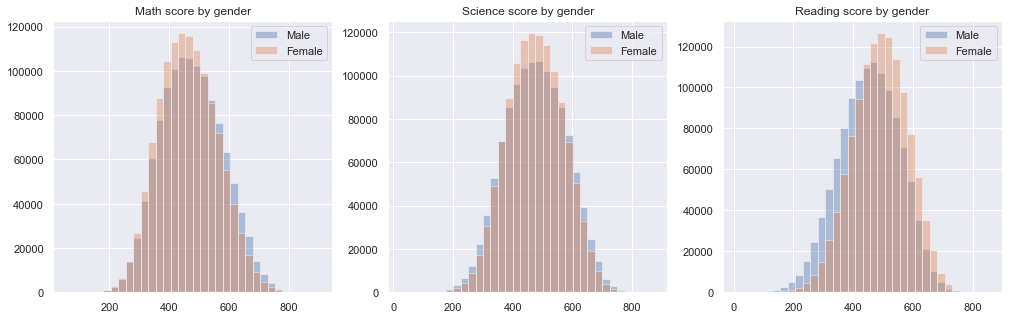

```python
plt.figure(figsize = [17, 5])

plt.subplot(1, 3, 1)


binsize=25
bins=np.arange(min(df['math score']),max(df['math score'])+binsize, binsize)

plt.title('Math score by gender')
plt.hist(data=df.query('gender=="Male"'),x='math score', alpha=.4,bins=bins, label='Male')
plt.hist(data=df.query('gender=="Female"'),x='math score', alpha=.4,bins=bins,label='Female')
plt.legend();

plt.subplot(1, 3, 2)


binsize=25
bins=np.arange(min(df['science score']),max(df['science score'])+binsize, binsize)

plt.title('Science score by gender')
plt.hist(data=df.query('gender=="Male"'),x='science score', alpha=.4,bins=bins, label='Male')
plt.hist(data=df.query('gender=="Female"'),x='science score', alpha=.4,bins=bins,label='Female')
plt.legend();

plt.subplot(1, 3, 3)

binsize=25
bins=np.arange(min(df['reading score']),max(df['reading score'])+binsize, binsize)

plt.title('Reading score by gender')
plt.hist(data=df.query('gender=="Male"'),x='reading score', alpha=.4,bins=bins, label='Male')
plt.hist(data=df.query('gender=="Female"'),x='reading score', alpha=.4,bins=bins,label='Female')
plt.legend();
```

According to the histograms :

- The Males students consistently score better than the Female students in Math.
- The Female students consistently score better than the Male students in Reading.

Let's move now to check if there is any correlation between math scores and science scores using a scatterplot

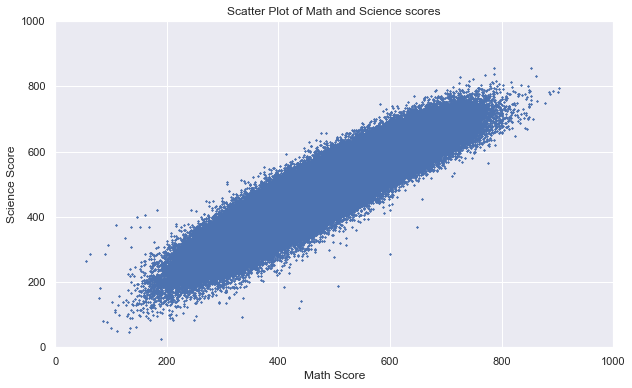

```python
plt.figure(figsize=(10, 6))
plt.xlim(0, 1000)
plt.ylim(0, 1000)
plt.xlabel('Math Score')
plt.ylabel('Science Score')
plt.plot(df['math score'], df['science score'], linestyle='', marker='o', markersize=0.7)
plt.title('Scatter Plot of Math and Science scores');
```

Math scores and science scores are correlated.  
What about reading scores is there a correlation between reading, math, and science scores, I will figure out this on the multivariate exploration part.

After this I am intersted in ranking countries by average score in maths, science and reading.

```python
# create new data frame of 10 countries with top math scores
country_math = df[['country' , 'math score']]
# calculate average math score
country_math = country_math.groupby('country').sum()/country_math.groupby('country').count()
# sort scores and select top 10
country_math = country_math.sort_values('math score', ascending = False)[0:10]

country_math = country_math.reset_index()
country_math
```

|  | country | math score |
| --- | --- | --- |
| 0 | China-Shanghai | 611.438933 |
| 1 | Singapore | 568.546974 |
| 2 | Hong Kong-China | 561.052123 |
| 3 | Chinese Taipei | 558.312010 |
| 4 | Korea | 553.752034 |
| 5 | Liechtenstein | 538.886608 |
| 6 | Macao-China | 538.319791 |
| 7 | Japan | 535.925248 |
| 8 | Estonia | 522.340803 |
| 9 | Switzerland | 520.968090 |

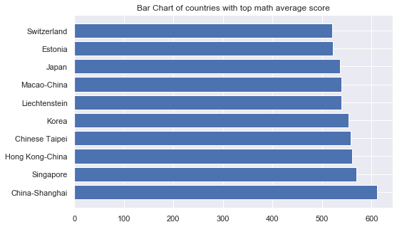

```python
# Bar graph of top math scores by country
plt.figure(figsize=(8, 5))
plt.barh(range(len(country_math.country)), country_math['math score'])
plt.yticks(range(len(country_math.country)),country_math.country)
plt.title('Bar Chart of countries with top math average score');
```

China_Shanghai has the highest math average score (above 600).  
the three pole positions are occupied by : China_Shanghai, Singapore, Honk_Kong

```python
# create new data frame of 10 countries with top science scores
country_science = df[['country' , 'science score']]
# calculate average science score
country_science = country_science.groupby('country').sum()/country_science.groupby('country').count()
# sort scores and select top 10
country_science = country_science.sort_values('science score', ascending = False)[0:10]

country_science = country_science.reset_index()
country_science
```

|  | country | science score |
| --- | --- | --- |
| 0 | China-Shanghai | 579.556540 |
| 1 | Hong Kong-China | 554.986433 |
| 2 | Singapore | 546.822920 |
| 3 | Japan | 546.413455 |
| 4 | Estonia | 543.241849 |
| 5 | Korea | 537.831998 |
| 6 | Poland | 528.245169 |
| 7 | Vietnam | 528.107704 |
| 8 | Finland | 527.664331 |
| 9 | Liechtenstein | 527.598522 |

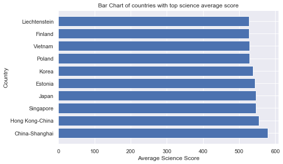

```python
# Bar graph of top sceicne scores by country
plt.figure(figsize=(8, 5))
plt.barh(range(len(country_science.country)), country_science['science score'])
plt.yticks(range(len(country_science.country)),country_science.country)
plt.xlabel('Average Science Score')
plt.ylabel('Country')
plt.title('Bar Chart of countries with top science average score');
```

Same results as Maths scores, China_Shanghai has the highest science average score .  
the three pole positions are occupied by : China_Shanghai, Honk_Kong, Singapore

```python
# create new data frame of 10 countries with top reading scores
country_reading = df[['country' , 'reading score']]
# calculate average reading score
country_reading = country_reading.groupby('country').sum()/country_reading.groupby('country').count()
# sort scores and select top 10
country_reading = country_reading.sort_values('reading score', ascending = False)[0:10]

country_reading = country_reading.reset_index()
country_reading
```

|  | country | reading score |
| --- | --- | --- |
| 0 | China-Shanghai | 568.629233 |
| 1 | Hong Kong-China | 544.521735 |
| 2 | Singapore | 537.742138 |
| 3 | Japan | 537.722484 |
| 4 | Korea | 535.805221 |
| 5 | Ireland | 523.596898 |
| 6 | Chinese Taipei | 522.185472 |
| 7 | Poland | 520.763584 |
| 8 | Massachusetts (USA) | 520.150401 |
| 9 | Liechtenstein | 518.275718 |

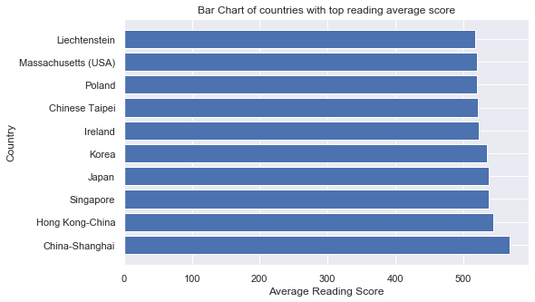

```python
# Bar graph of top reading scores by country
plt.figure(figsize=(8, 5))
plt.barh(range(len(country_reading.country)), country_reading['reading score'])
plt.yticks(range(len(country_reading.country)),country_reading.country)
plt.xlabel('Average Reading Score')
plt.ylabel('Country')
plt.title('Bar Chart of countries with top reading average score');
```

Same results as Math and science scores, China_Shanghai has the highest science average score .  
the three pole positions are occupied by : China_Shanghai, Honk_Kong, Singapore

```python
df.head()
```

|  | student id | country | gender | age | discipline | discipline level | math score | reading score | science score |
| --- | --- | --- | --- | --- | --- | --- | --- | --- | --- |
| 0 | 1 | Albania | Female | 6.0 | students don’t listen | Never or Hardly Ever | 366.18634 | 261.01424 | 371.91348 |
| 1 | 2 | Albania | Female | 7.0 | students don’t listen | NaN | 470.56396 | 384.68832 | 478.12382 |
| 2 | 3 | Albania | Female | 6.0 | students don’t listen | NaN | 505.53824 | 405.18154 | 486.60946 |
| 3 | 4 | Albania | Female | 6.0 | students don’t listen | Never or Hardly Ever | 449.45476 | 477.46376 | 453.97240 |
| 4 | 5 | Albania | Female | 6.0 | students don’t listen | Some Lessons | 385.50398 | 256.01010 | 367.15778 |

### 3. Multivariate exploration and analysis

Let's explore the pair-by-pair relationship between math scores, reading scores and science scores, and correlate them in pair scatter plots, in order to see what type and strength of correlation exists.

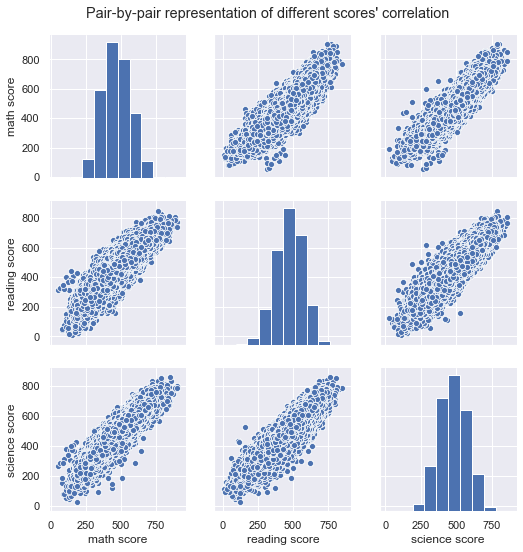

```python
plt.figure(figsize=(17, 17))
grid = sns.pairplot(data = df, vars=["math score", "reading score", "science score"]);
grid.fig.suptitle("Pair-by-pair representation of different scores' correlation", y = 1.02);
```

As it could be expected, there is a very strong and positive correlation between any pair of the three variables representing the scores of the three subjects.

Using Faceting visualization I will depict the distribution of math scores, given five discipline metrics :

```
- noise and disporder
- student don't listen
- students don't work well
- students start working late
- teacher has to wail until its quiet
```

For each metric there is four levels :

```
- Never or hardly ever
- Some lessons
- Most lesons
- Every lesson
```

For this part the best visualization to depict th relation betwen two categorical variable : 'discipline' and 'discipline level' and one quatitative variable 'math score' is a facetting boxplots.

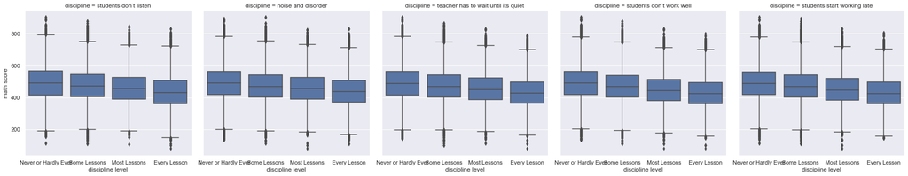

```python
# set order for categorical variable
df['discipline level'] = df['discipline level'].astype('category')
df['discipline level'].cat.reorder_categories(['Never or Hardly Ever',
                                               'Some Lessons', 'Most Lessons', 'Every Lesson'], inplace=True)
# Facetting plot math score
g = sns.FacetGrid(data = df , col = 'discipline', size = 5, margin_titles = True)
g.map(sns.boxplot, 'discipline level', 'math score');
```

For all discipline metrics, when discipline level is high 'never or hardly ever' math scores are high. the less the level of discipline is the less is the score of math.

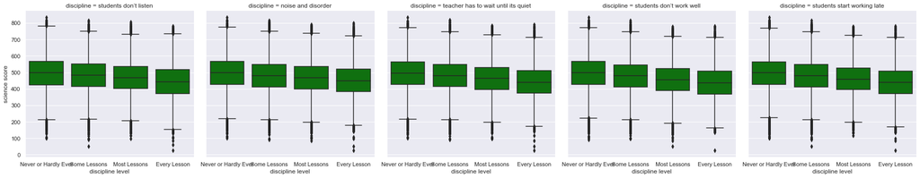

```python
# Facetting plot science score
g = sns.FacetGrid(data = df , col = 'discipline', size = 5, margin_titles = True)
g.map(sns.boxplot, 'discipline level', 'science score', color ='green');
```

For all discipline metrics, when discipline level is high 'never or hardly ever' science scores are high. the less the level of discipline is the less is the science score

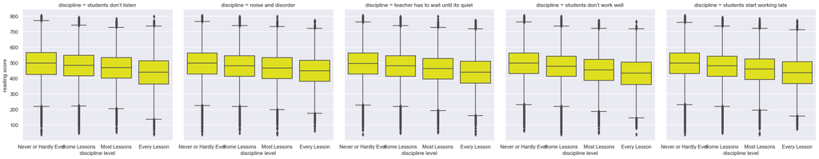

```python
# Facetting plot reading score
g = sns.FacetGrid(data = df , col = 'discipline', size = 5, margin_titles = True)
g.map(sns.boxplot, 'discipline level', 'reading score', color ='yellow');
```

For all discipline metrics, when discipline level is high 'never or hardly ever' reading scores are high. the less the level of discipline is the less is the reading score